# BT1101-Tutorial 5 (Part 2 Deadline: 11 Mar 9am)

#### Q2.(c) Comparing customer usage and exercise pattern

There are two variables that capture the customers usage and exercise pattern: `Usage` and `Miles`.

- 1. Test if there is any significant difference in mean `Usage` across the 3 products - TM195, TM498 versus TM798 (3 marks)
- 2. Repeat the above test (i) for `Miles`.(3 marks)
- 3. Test if the mean `Miles` for customers is higher for customers with “High” fitness versus those with “Low” fitness. “High” fitness is defined by customers with a self-rated fitness score that is greater than the median while “Low” fitness is defined by customer with a self-rated fitness score equal or lower than the median. (Hint: You can create a categorical variable for the two levels of Fitness.) (4 marks)

Set up the appropriate hypotheses and conduct the hypotheses tests using 5% significance level. Type your hypotheses and findings in the space below.

For tutorial discussion: Based on your analyses of the CardioGoodFitness restore, discuss how you think the 3 types of treadmills may differ (e.g. in terms of the features or customers that are attracted to the product).

**BEGIN: YOUR ANSWER**

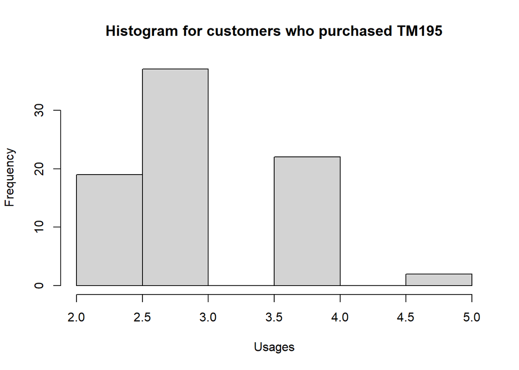

```r
## Type your codes here

# i
# H0: mean usage of cust who purchased TM195 = that of TM498 = that of TM798
# H1: at least 1 is different from the others

# checking assumptions for ANOVA:
# 1. data points are independent (assumed to be true due to random sampling)

# 2. within each group, data is normally distributed
# tm195 <- d1 %>% filter(Product == "TM195")
# tm498 <- d1 %>% filter(Product == "TM498")
# tm798 <- d1 %>% filter(Product == "TM798")
# plot histograms
hist(tm195$Usage, main = "Histogram for customers who purchased TM195", xlab = "Usages")
```

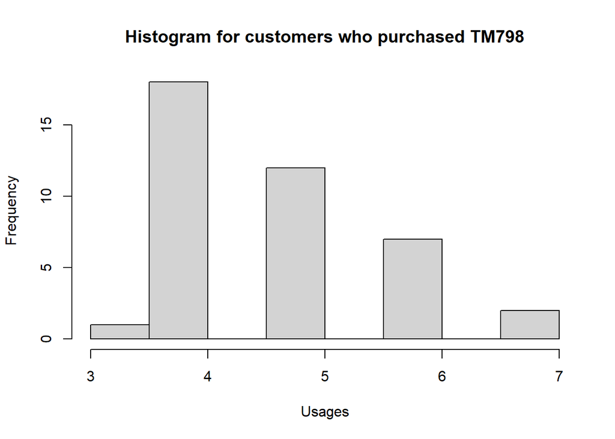

```r
hist(tm798$Usage, main = "Histogram for customers who purchased TM798", xlab = "Usages")
```

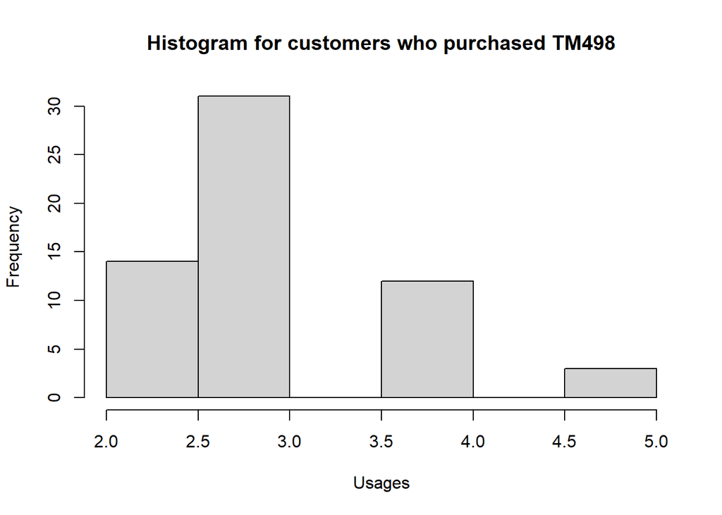

```r
hist(tm498$Usage, main = "Histogram for customers who purchased TM498", xlab = "Usages")
```